# Lecture 5. Ensemble Learning

**Crowd intelligence**

Joaquin Vanschoren

## Ensemble learning

- If different models make different mistakes, can we simply average the predictions?
- Voting Classifier: gives every model a *vote* on the class label
  - Hard vote: majority class wins (class order breaks ties)
  - Soft vote: sum class probabilities $p_{m,c}$ over $M$ models: $\underset{c}{\operatorname{argmax}} \sum_{m=1}^{M} w_c p_{m,c}$
  - Classes can get different weights $w_c$ (default: $w_c=1$)

```
interactive(children=(Dropdown(description='model1', options=(LogisticRegression(C=100), DecisionTreeClassifie…
```

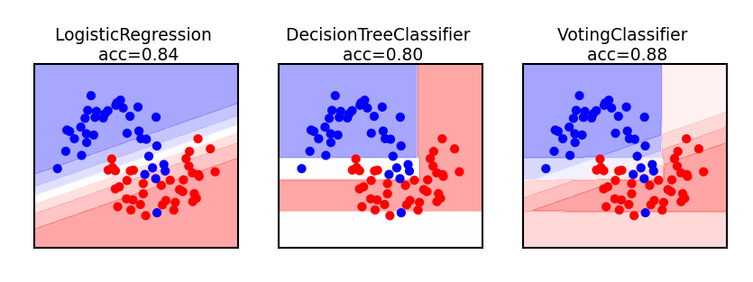

- Why does this work?
  - Different models may be good at different 'parts' of data (even if they underfit)
  - Individual mistakes can be 'averaged out' (especially if models overfit)
- Which models should be combined?
- Bias-variance analysis teaches us that we have two options:
  - If model underfits (high bias, low variance): combine with other low-variance models
    - Need to be different: 'experts' on different parts of the data
    - Bias reduction. Can be done with *Boosting*
  - If model overfits (low bias, high variance): combine with other low-bias models
    - Need to be different: individual mistakes must be different
    - Variance reduction. Can be done with *Bagging*
- Models must be uncorrelated but good enough (otherwise the ensemble is worse)
- We can also *learn* how to combine the predictions of different models: *Stacking*

## Decision trees (recap)

- Representation: Tree that splits data points into leaves based on tests
- Evaluation (loss): Heuristic for purity of leaves (Gini index, entropy,...)
- Optimization: Recursive, heuristic greedy search (Hunt's algorithm)
  - Consider all splits (thresholds) between adjacent data points, for every feature
  - Choose the one that yields the purest leafs, repeat

```
interactive(children=(IntSlider(value=3, description='depth', max=5, min=1), Output()), _dom_classes=('widget-…
```

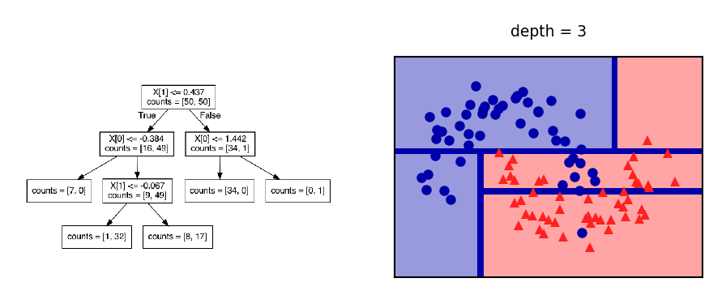

### Evaluation (loss function for classification)

- Every leaf predicts a class probability $\hat{p}_c$ = the relative frequency of class $c$
- Leaf impurity measures (splitting criteria) for $L$ leafs, leaf $l$ has data $X_l$:
  - Gini-Index: $Gini(X_{l}) = \sum_{c\neq c'} \hat{p}_c \hat{p}_{c'}$
  - Entropy (more expensive): $E(X_{l}) = -\sum_{c\neq c'} \hat{p}_c \log_{2}\hat{p}_c$
  - Best split maximizes *information gain* (idem for Gini index) $$ Gain(X,X_i) = E(X) - \sum_{l=1}^L \frac{|X_{i=l}|}{|X_{i}|} E(X_{i=l}) $$

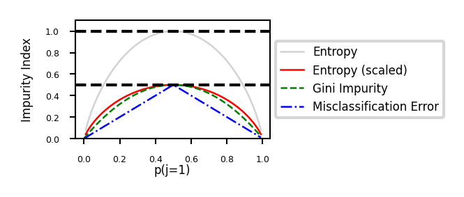

### Regression trees

- Every leaf predicts the *mean* target value $\mu$ of all points in that leaf
- Choose the split that minimizes squared error of the leaves: $\sum_{x_{i} \in L} (y_i - \mu)^2$
- Yields non-smooth step-wise predictions, cannot extrapolate

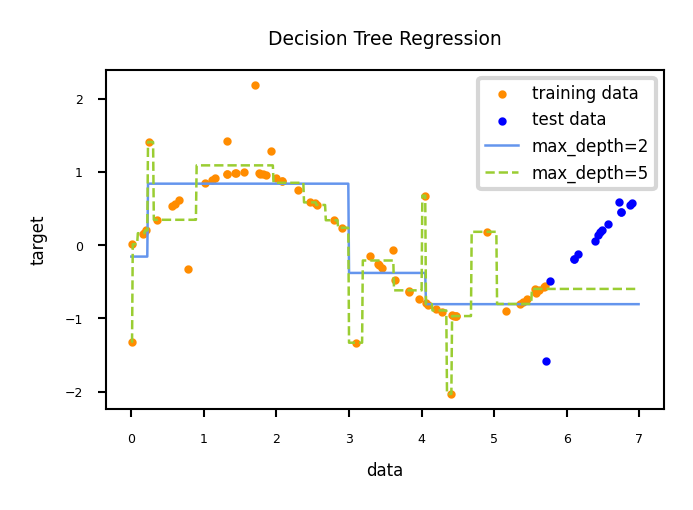

### Impurity/Entropy-based feature importance

- We can measure the importance of features (to the model) based on
  - Which features we split on
  - How high up in the tree we split on them (first splits ar emore important)

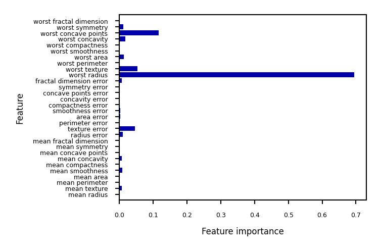

### Under- and overfitting

- We can easily control the (maximum) depth of the trees as a hyperparameter
- Bias-variance analysis:
  - Shallow trees have high bias but very low variance (underfitting)
  - Deep trees have high variance but low bias (overfitting)
- Because we can easily control their complexity, they are ideal for ensembling
  - Deep trees: keep low bias, reduce variance with *Bagging*
  - Shallow trees: keep low variance, reduce bias with *Boosting*

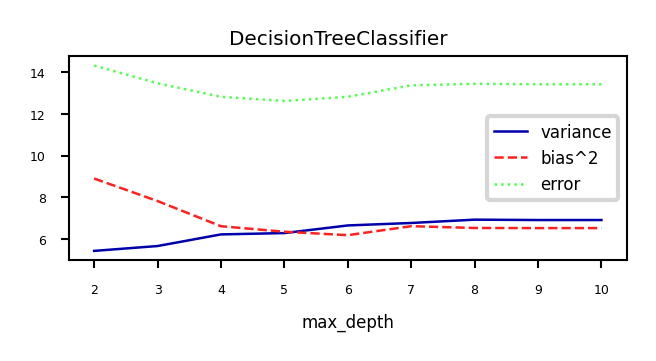

## Bagging (Bootstrap Aggregating)

- Obtain different models by training the *same* model on *different training samples*
  - Reduce overfitting by averaging out individual predictions (variance reduction)
- In practice: take $I$ bootstrap samples of your data, train a model on each bootstrap
  - Higher $I$: more models, more smoothing (but slower training and prediction)
- Base models should be unstable: different training samples yield different models
  - E.g. very deep decision trees, or even randomized decision trees
  - Deep Neural Networks can also benefit from bagging (deep ensembles)
- Prediction by averaging predictions of base models
  - Soft voting for classification (possibly weighted)
  - Mean value for regression
- Can produce uncertainty estimates as well
  - By combining class probabilities of individual models (or variances for regression)

### Random Forests

- Uses *randomized trees* to make models even less correlated (more unstable)
  - At every split, only consider `max_features` features, randomly selected
- Extremely randomized trees: considers 1 random threshold for random set of features (faster)

```
interactive(children=(Dropdown(description='model', options=(RandomForestClassifier(n_estimators=5, n_jobs=-1,…
```

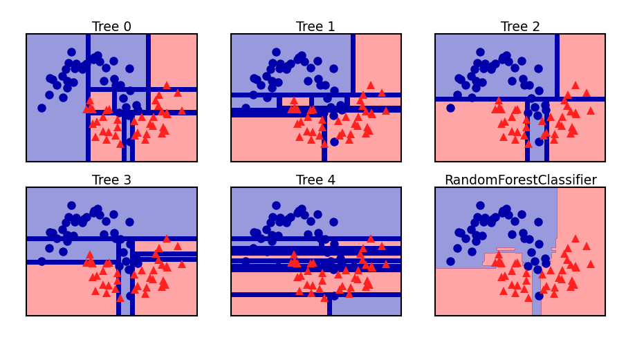

### Effect on bias and variance

- Increasing the number of models (trees) decreases variance (less overfitting)
- Bias is mostly unaffected, but will increase if the forest becomes too large (oversmoothing)

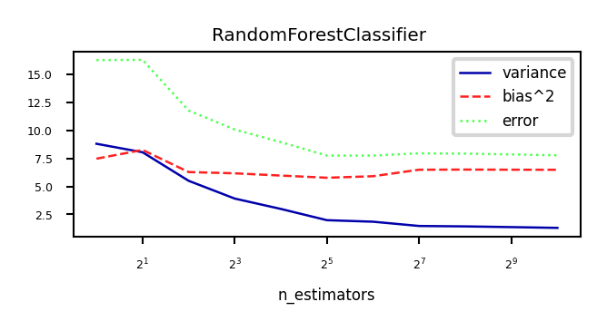

#### In practice

- Different implementations can be used. E.g. in scikit-learn:
  - `BaggingClassifier`: Choose your own base model and sampling procedure
  - `RandomForestClassifier`: Default implementation, many options
  - `ExtraTreesClassifier`: Uses extremely randomized trees
- Most important parameters:
  - `n_estimators` (>100, higher is better, but diminishing returns)
    - Will start to underfit (bias error component increases slightly)
  - `max_features`
    - Defaults: $sqrt(p)$ for classification, $log2(p)$ for regression
    - Set smaller to reduce space/time requirements
  - parameters of trees, e.g. `max_depth`, `min_samples_split`,...
    - Prepruning useful to reduce model size, but don't overdo it
- Easy to parallelize (set `n_jobs` to -1)
- Fix `random_state` (bootstrap samples) for reproducibility

### Out-of-bag error

- RandomForests don't need cross-validation: you can use the out-of-bag (OOB) error
- For each tree grown, about 33% of samples are out-of-bag (OOB)
  - Remember which are OOB samples for every model, do voting over these
- OOB error estimates are great to speed up model selection
  - As good as CV estimates, althought slightly pessimistic
- In scikit-learn: `oob_error = 1 - clf.oob_score_`

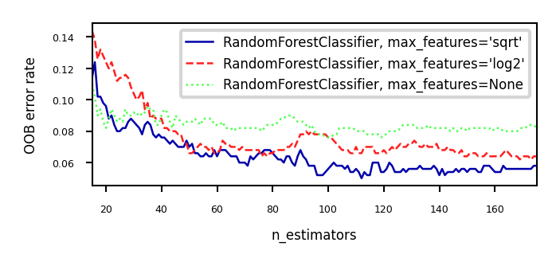

### Feature importance

- RandomForests provide more reliable feature importances, based on many alternative hypotheses (trees)

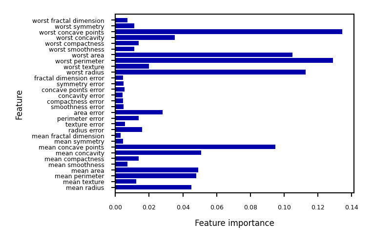

### Other tips

- Model calibration
  - RandomForests are poorly calibrated.
  - Calibrate afterwards (e.g. isotonic regression) if you aim to use probabilities
- Warm starting
  - Given an ensemble trained for $I$ iterations, you can simply add more models later
  - You *warm start* from the existing model instead of re-starting from scratch
  - Can be useful to train models on new, closely related data
    - Not ideal if the data batches change over time (concept drift)
    - Boosting is more robust against this (see later)

### Strength and weaknesses

- RandomForest are among most widely used algorithms:
  - Don't require a lot of tuning
  - Typically very accurate
  - Handles heterogeneous features well (trees)
  - Implictly selects most relevant features
- Downsides:
  - less interpretable, slower to train (but parallellizable)
  - don't work well on high dimensional sparse data (e.g. text)

## Adaptive Boosting (AdaBoost)

- Obtain different models by *reweighting* the training data every iteration
  - Reduce underfitting by focusing on the 'hard' training examples
- Increase weights of instances misclassified by the ensemble, and vice versa
- Base models should be simple so that different instance weights lead to different models
  - Underfitting models: decision stumps (or very shallow trees)
  - Each is an 'expert' on some parts of the data
- Additive model: Predictions at iteration $I$ are sum of base model predictions
  - In Adaboost, also the models each get a unique weight $w_i$ $$f_I(\mathbf{x}) = \sum_{i=1}^I w_i g_i(\mathbf{x})$$
- Adaboost minimizes exponential loss. For instance-weighted error $\varepsilon$: $$\mathcal{L}_{Exp} = \sum_{n=1}^N e^{\varepsilon(f_I(\mathbf{x}))}$$
- By deriving $\frac{\partial \mathcal{L}}{\partial w_i}$ you can find that optimal $w_{i} = \frac{1}{2}\log(\frac{1-\varepsilon}{\varepsilon})$

### AdaBoost algorithm

- Initialize sample weights: $s_{n,0} = \frac{1}{N}$
- Build a model (e.g. decision stumps) using these sample weights
- Give the *model* a weight $w_i$ related to its weighted error rate $\varepsilon$ $$w_{i} = \lambda\log(\frac{1-\varepsilon}{\varepsilon})$$
  - Good trees get more weight than bad trees
  - Logit function maps error $\varepsilon$ from [0,1] to weight in [-Inf,Inf] (use small minimum error)
  - Learning rate $\lambda$ (shrinkage) decreases impact of individual classifiers
    - Small updates are often better but requires more iterations
- Update the sample weights
  - Increase weight of incorrectly predicted samples: $s_{n,i+1} = s_{n,i}e^{w_i}$
  - Decrease weight of correctly predicted samples: $s_{n,i+1} = s_{n,i}e^{-w_i}$
  - Normalize weights to add up to 1
- Repeat for $I$ iterations

### AdaBoost variants

- Discrete Adaboost: error rate $\varepsilon$ is simply the error rate (1-Accuracy)
- Real Adaboost: $\varepsilon$ is based on predicted class probabilities $\hat{p}_c$ (better)
- AdaBoost for regression: $\varepsilon$ is either linear ($|y_i-\hat{y}_i|$), squared ($(y_i-\hat{y}_i)^2$), or exponential loss
- GentleBoost: adds a bound on model weights $w_i$
- LogitBoost: Minimizes logistic loss instead of exponential loss $$\mathcal{L}_{Logistic} = \sum_{n=1}^N log(1+e^{\varepsilon(f_I(\mathbf{x}))})$$

### Adaboost in action

- Size of the samples represents sample weight
- Background shows the latest tree's predictions

```
interactive(children=(IntSlider(value=30, description='iteration', max=60), Output()), _dom_classes=('widget-i…
```

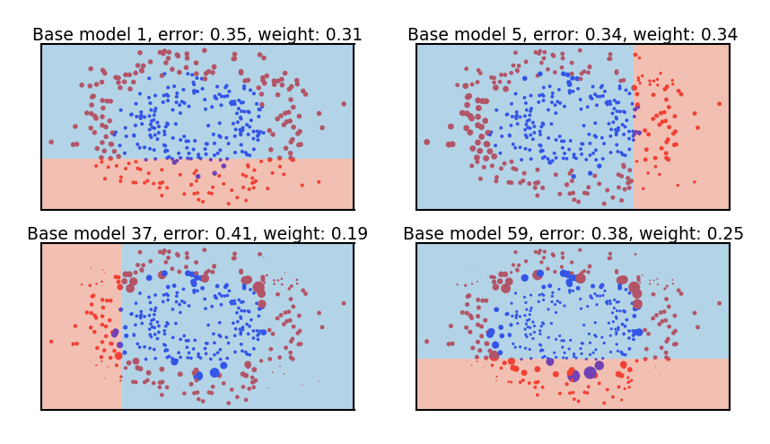

### Examples

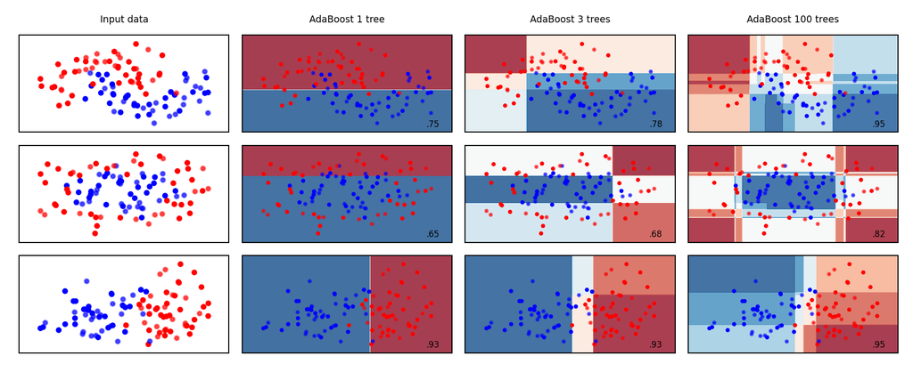

### Bias-Variance analysis

- AdaBoost reduces bias (and a little variance)
  - Boosting is a *bias reduction* technique
- Boosting too much will eventually increase variance

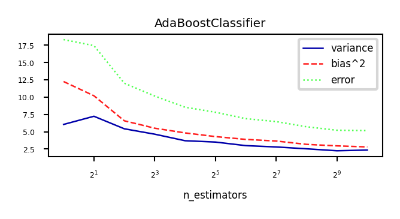

## Gradient Boosting

- Ensemble of models, each fixing the remaining mistakes of the previous ones
  - Each iteration, the task is to predict the *residual error* of the ensemble
- Additive model: Predictions at iteration $I$ are sum of base model predictions
  - Learning rate (or *shrinkage* ) $\eta$: small updates work better (reduces variance) $$f_I(\mathbf{x}) = g_0(\mathbf{x}) + \sum_{i=1}^I \eta \cdot g_i(\mathbf{x}) = f_{I-1}(\mathbf{x}) + \eta \cdot g_I(\mathbf{x})$$
- The *pseudo-residuals* $r_i$ are computed according to differentiable loss function
  - E.g. least squares loss for regression and log loss for classification
  - Gradient descent: *predictions* get updated step by step until convergence $$g_i(\mathbf{x}) \approx r_{i} = - \frac{\partial \mathcal{L}(y_i,f_{i-1}(x_i))}{\partial f_{i-1}(x_i)}$$
- Base models $g_i$ should be low variance, but flexible enough to predict residuals accurately
  - E.g. decision trees of depth 2-5

### Gradient Boosting Trees (Regression)

- Base models are regression trees, loss function is square loss: $\mathcal{L} = \frac{1}{2}(y_i - \hat{y}_i)^2$
- The pseudo-residuals are simply the prediction errors for every sample: $$r_i = -\frac{\partial \mathcal{L}}{\partial \hat{y}} = -2 * \frac{1}{2}(y_i - \hat{y}_i) * (-1) = y_i - \hat{y}_i$$
- Initial model $g_0$ simply predicts the mean of $y$
- For iteration $m=1..M$:
  - For all samples i=1..n, compute pseudo-residuals $r_i = y_i - \hat{y}_i$
  - Fit a new regression tree model $g_m(\mathbf{x})$ to $r_{i}$
    - In $g_m(\mathbf{x})$, each leaf predicts the mean of all its values
  - Update ensemble predictions $\hat{y} = g_0(\mathbf{x}) + \sum_{m=1}^M \eta \cdot g_m(\mathbf{x})$
- Early stopping (optional): stop when performance on validation set does not improve for $nr$ iterations

#### Gradient Boosting Regression in action

- Residuals quickly drop to (near) zero

```
interactive(children=(IntSlider(value=30, description='step', max=60), Output()), _dom_classes=('widget-intera…
```

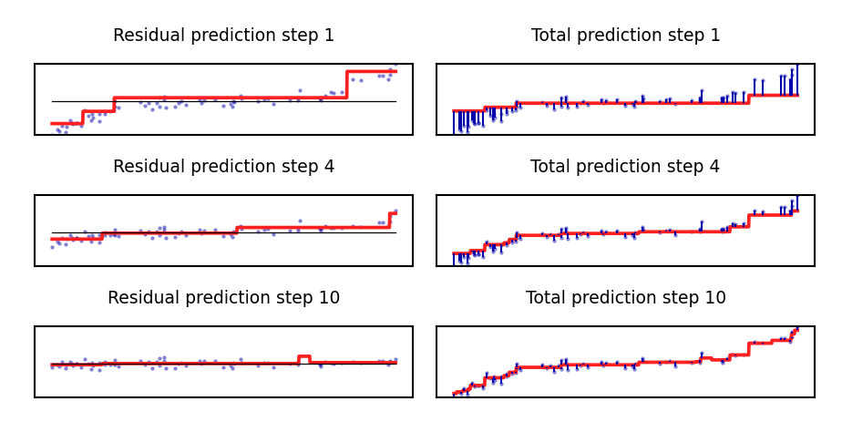

### GradientBoosting Algorithm (Classification)

- Base models are *regression* trees, predict probability of positive class $p$
  - For multi-class problems, train one tree per class
- Use (binary) log loss, with true class $y_i \in {0,1}$: $\mathcal{L_{log}} = - \sum_{i=1}^{N} \big[ y_i log(p_i) + (1-y_i) log(1-p_i) \big] $
- The pseudo-residuals are simply the difference between true class and predicted $p$: $$\frac{\partial \mathcal{L}}{\partial \hat{y}} = \frac{\partial \mathcal{L}}{\partial log(p_i)} = y_i - p_i$$
- Initial model $g_0$ predicts $p = log(\frac{\#positives}{\#negatives})$
- For iteration $m=1..M$:
  - For all samples i=1..n, compute pseudo-residuals $r_i = y_i - p_i$
  - Fit a new regression tree model $g_m(\mathbf{x})$ to $r_{i}$
    - In $g_m(\mathbf{x})$, each leaf predicts $\frac{\sum_{i} r_i}{\sum_{i} p_i(1-p_i)}$
  - Update ensemble predictions $\hat{y} = g_0(\mathbf{x}) + \sum_{m=1}^M \eta \cdot g_m(\mathbf{x})$
- Early stopping (optional): stop when performance on validation set does not improve for $nr$ iterations

#### Gradient Boosting Classification in action

- Size of the samples represents the residual weights: most quickly drop to (near) zero

```
interactive(children=(IntSlider(value=30, description='iteration', max=60, min=1), Output()), _dom_classes=('w…
```

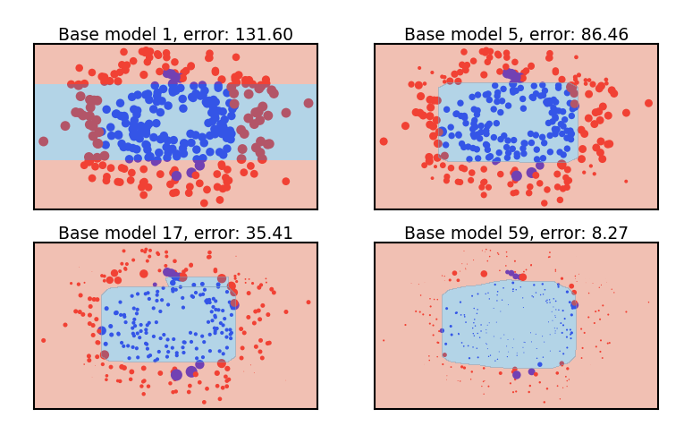

#### Examples

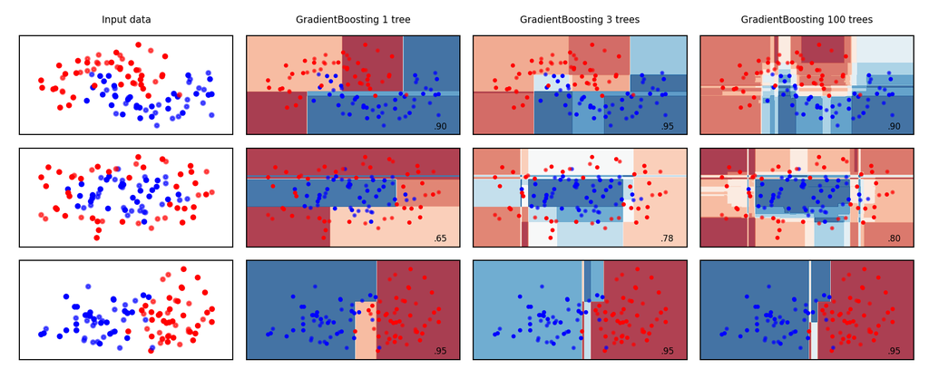

#### Bias-variance analysis

- Gradient Boosting is very effective at reducing bias error
- Boosting too much will eventually increase variance

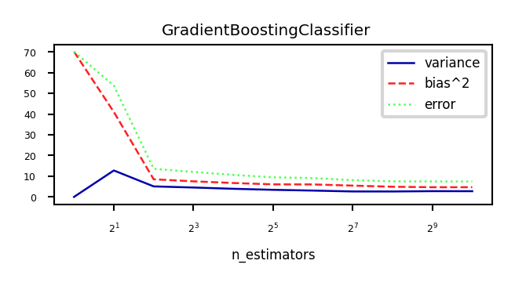

#### Feature importance

- Gradient Boosting also provide feature importances, based on many trees
- Compared to RandomForests, the trees are smaller, hence more features have zero importance

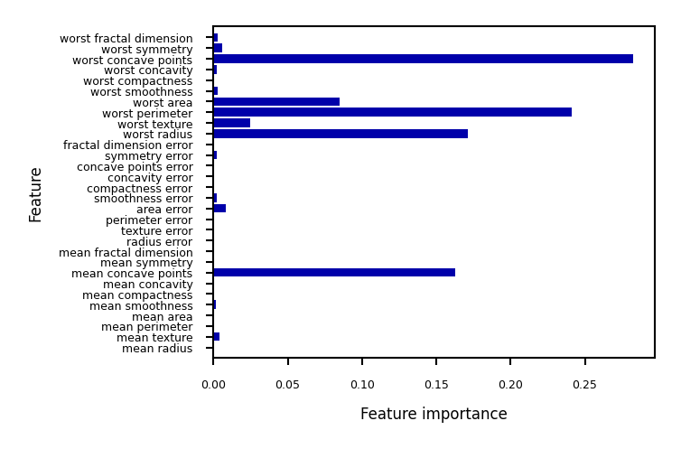

#### Gradient Boosting: strengths and weaknesses

- Among the most powerful and widely used models
- Work well on heterogeneous features and different scales
- Typically better than random forests, but requires more tuning, longer training
- Does not work well on high-dimensional sparse data

Main hyperparameters:

- `n_estimators`: Higher is better, but will start to overfit
- `learning_rate`: Lower rates mean more trees are needed to get more complex models
  - Set `n_estimators` as high as possible, then tune `learning_rate`
  - Or, choose a `learning_rate` and use early stopping to avoid overfitting
- `max_depth`: typically kept low (<5), reduce when overfitting
- `max_features`: can also be tuned, similar to random forests
- `n_iter_no_change`: early stopping: algorithm stops if improvement is less than a certain tolerance `tol` for more than `n_iter_no_change` iterations.

### Extreme Gradient Boosting (XGBoost)

- Faster version of gradient boosting: allows more iterations on larger datasets
- Normal regression trees: split to minimize squared loss of leaf predictions
  - XGBoost trees only fit residuals: split so that residuals in leaf are more *similar*
- Don't evaluate every split point, only $q$ *quantiles* per feature (binning)
  - $q$ is hyperparameter (`sketch_eps`, default 0.03)
- For large datasets, XGBoost uses *approximate quantiles*
  - Can be parallelized (multicore) by chunking the data and combining histograms of data
  - For classification, the quantiles are weighted by $p(1-p)$
- Gradient descent sped up by using the second derivative of the loss function
- Strong regularization by pre-pruning the trees
- Column and row are randomly subsampled when computing splits
- Support for out-of-core computation (data compression in RAM, sharding,...)

#### XGBoost in practice

- Not part of scikit-learn, but `HistGradientBoostingClassifier` is similar
  - binning, multicore,...
- The `xgboost` python package is sklearn-compatible
  - Install separately, `conda install -c conda-forge xgboost`
  - Allows learning curve plotting and warm-starting
- Further reading:
  - [XGBoost Documentation](https://xgboost.readthedocs.io/en/latest/parameter.html#parameters-for-tree-booster)
  - [Paper](http://arxiv.org/abs/1603.02754)
  - [Video](https://www.youtube.com/watch?v=oRrKeUCEbq8)

### LightGBM

Another fast boosting technique

- Uses *gradient-based sampling*
  - use all instances with large gradients/residuals (e.g. 10% largest)
  - randomly sample instances with small gradients, ignore the rest
  - intuition: samples with small gradients are already well-trained.
  - requires adapted information gain criterion
- Does smarter encoding of categorical features

### CatBoost

Another fast boosting technique

- Optimized for categorical variables
  - Uses bagged and smoothed version of target encoding
- Uses symmetric trees: same split for all nodes on a given level aka
  - Can be much faster
- Allows monotonicity constraints for numeric features
  - Model must be be a non-decreasing function of these features
- Lots of tooling (e.g. GPU training)

## Stacking

- Choose $M$ different base-models, generate predictions
- Stacker (meta-model) learns mapping between predictions and correct label
  - Can also be repeated: multi-level stacking
  - Popular stackers: linear models (fast) and gradient boosting (accurate)
- Cascade stacking: adds base-model predictions as extra features
- Models need to be sufficiently different, be experts at different parts of the data
- Can be *very* accurate, but also very slow to predict

[figure not shown]

## Other ensembling techniques

- Hyper-ensembles: same basic model but with different hyperparameter settings
  - Can combine overfitted and underfitted models
- Deep ensembles: ensembles of deep learning models
- Bayes optimal classifier: ensemble of all possible models (largely theoretic)
- Bayesian model averaging: weighted average of probabilistic models, weighted by their posterior probabilities
- Cross-validation selection: does internal cross-validation to select best of $M$ models
- Any combination of different ensembling techniques

### Algorithm overview

| Name | Representation | Loss function | Optimization | Regularization |
| --- | --- | --- | --- | --- |
| Classification trees | Decision tree | Entropy / Gini index | Hunt's algorithm | Tree depth,... |
| Regression trees | Decision tree | Square loss | Hunt's algorithm | Tree depth,... |
| RandomForest | Ensemble of randomized trees | Entropy / Gini / Square | (Bagging) | Number/depth of trees,... |
| AdaBoost | Ensemble of stumps | Exponential loss | Greedy search | Number/depth of trees,... |
| GradientBoostingRegression | Ensemble of regression trees | Square loss | Gradient descent | Number/depth of trees,... |
| GradientBoostingClassification | Ensemble of regression trees | Log loss | Gradient descent | Number/depth of trees,... |
| XGBoost, LightGBM, CatBoost | Ensemble of XGBoost trees | Square/log loss | 2nd order gradients | Number/depth of trees,... |
| Stacking | Ensemble of heterogeneous models | / | / | Number of models,... |

### Summary

- Ensembles of voting classifiers improve performance
  - Which models to choose? Consider bias-variance tradeoffs!
- Bagging / RandomForest is a variance-reduction technique
  - Build many high-variance (overfitting) models on random data samples
    - The more different the models, the better
  - Aggregation (soft voting) over many models reduces variance
    - Diminishing returns, over-smoothing may increase bias error
  - Parallellizes easily, doesn't require much tuning
- Boosting is a bias-reduction technique
  - Build low-variance models that correct each other's mistakes
    - By reweighting misclassified samples: AdaBoost
    - By predicting the residual error: Gradient Boosting
  - Additive models: predictions are sum of base-model predictions
    - Can drive the error to zero, but risk overfitting
  - Doesn't parallelize easily. Slower to train, much faster to predict.
    - XGBoost,LightGBM,... are fast and offer some parallellization
- Stacking: learn how to combine base-model predictions
  - Base-models still have to be sufficiently different